# Resolução da Lista de Exercícios 1

Prof. Washington S. da Silva

### Questão 1

**a.**

```r
x <- 10*30
x
```

```
## [1] 300
```

**b.**

```r
y <- seq(1:100)
length(y)
```

```
## [1] 100
```

**c.**

```r
ls()
```

```
## [1] "x" "y"
```

**d.**

```r
rm(x,y)
ls()
```

```
## character(0)
```

### Questão 2

**a.** Os principais tipos atômicos para representação de dados na linguagem R estão descitos no quadro a seguir:

| Tipos | Descrição |
| --- | --- |
| `double` | um vetor contendo números reais |
| `integer` | um vetor contendo números inteiros |
| `character` | um vetor contendo caracteres |
| `logical` | um vetor contendo valores lógicos |
| `complex` | um vetor contendo números complexos |
| `NA` | `Not Available`: representa dados faltantes |
| `NaN` | `Not a Number`: 0/0, 1/0, etc. |
| `Inf` | $+ \infty$ ou $- \infty$ |

**b.** As principais estruturas para representação de dados na linguagem R são:

| Estrutura | Descrição |
| --- | --- |
| `vector` | elementos devem ser o mesmo tipo. |
| `matrix`. | elementos devem ser do tipo numérico (double ou integer). |
| `data.frame` ou `tibble`. | colunas podem ser de tipos diferentes. É a estrutura mais usual |
|  | para a análise de dados. |
| `array` | elementos devem ser do mesmo tipo, mas com mais dimensões. |
| `list` | elementos podem ser de diferentes tipos, incluindo |
|  | estruturas como vetores, data frames etc. É a |
|  | estrutura de dados mais flexível. |

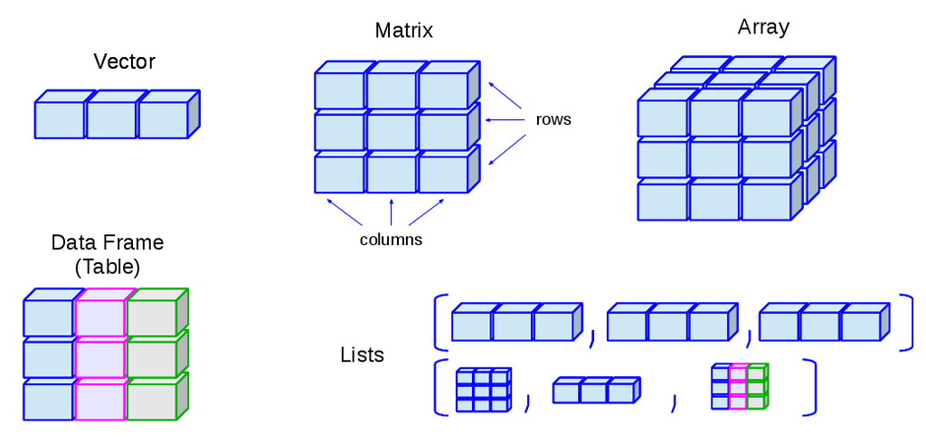

### Questão 3

**a.**

```r
vendas <- c(653, 552, 748, 658, 502, 310, 160)
custo <- c(243, 218, 283, 284, 212, 98, 110)
```

**b.**

```r
length(vendas)
```

```
## [1] 7
```

```r
length(custo)
```

```
## [1] 7
```

**c.**

```r
lucro <- vendas - custo
lucro
```

```
## [1] 410 334 465 374 290 212  50
```

**d.**

Podemos utilizar a função `replace()`

```r
vendas <- replace(vendas, vendas == 310, 130)
lucro <- vendas - custo
lucro
```

```
## [1] 410 334 465 374 290  32  50
```

É sempre importante lembrar que, em geral, há várias possibilidades para se resolver uma tarefa com uma linguagem de programação.

Outro método possível para corrigir o valor é: `vendas[x == 310] <- 130`

**e.**

```r
lucro_total <- sum(lucro)
lucro_total
```

```
## [1] 1955
```

```r
lucro_medio_diario <- mean(lucro)
lucro_medio_diario
```

```
## [1] 279.3
```

### Questão 4

```r
i <- 0.006
for (j in 1:1000) {
   i <- (1 - (1 + i)^(-20))/19
}

i
```

```
## [1] 0.004936
```

### Questão 5

**a.**

```r
# ativando os pacotes
library(dplyr)
library(gapminder)

brasil <- gapminder |> filter(country == "Brazil")
head(brasil)
```

```
## # A tibble: 6 × 6
##   country continent  year lifeExp       pop gdpPercap
##   <fct>   <fct>     <int>   <dbl>     <int>     <dbl>
## 1 Brazil  Americas   1952    50.9  56602560     2109.
## 2 Brazil  Americas   1957    53.3  65551171     2487.
## 3 Brazil  Americas   1962    55.7  76039390     3337.
## 4 Brazil  Americas   1967    57.6  88049823     3430.
## 5 Brazil  Americas   1972    59.5 100840058     4986.
## 6 Brazil  Americas   1977    61.5 114313951     6660.
```

**b.**

```r
gapminder |> filter(lifeExp < 30)
```

```
## # A tibble: 2 × 6
##   country     continent  year lifeExp     pop gdpPercap
##   <fct>       <fct>     <int>   <dbl>   <int>     <dbl>
## 1 Afghanistan Asia       1952    28.8 8425333      779.
## 2 Rwanda      Africa     1992    23.6 7290203      737.
```

**c.**

```r
gapminder |> filter(country %in% c("Brazil", "Argentina"))
```

```
## # A tibble: 24 × 6
##    country   continent  year lifeExp      pop gdpPercap
##    <fct>     <fct>     <int>   <dbl>    <int>     <dbl>
##  1 Argentina Americas   1952    62.5 17876956     5911.
##  2 Argentina Americas   1957    64.4 19610538     6857.
##  3 Argentina Americas   1962    65.1 21283783     7133.
##  4 Argentina Americas   1967    65.6 22934225     8053.
##  5 Argentina Americas   1972    67.1 24779799     9443.
##  6 Argentina Americas   1977    68.5 26983828    10079.
##  7 Argentina Americas   1982    69.9 29341374     8998.
##  8 Argentina Americas   1987    70.8 31620918     9140.
##  9 Argentina Americas   1992    71.9 33958947     9308.
## 10 Argentina Americas   1997    73.3 36203463    10967.
## # ℹ 14 more rows
```

**d.**

dados sobre esperança de vida (lifeExp), população (pop) e Pib per capita (gdpPercap) apenas para o Brasil:

```r
gapminder |>
    filter(country == "Brazil", year == 2007) |>
          select(country, lifeExp, pop, gdpPercap)
```

```
## # A tibble: 1 × 4
##   country lifeExp       pop gdpPercap
##   <fct>     <dbl>     <int>     <dbl>
## 1 Brazil     72.4 190010647     9066.
```

Podemos verificar que estimativa da esperança de vida média para o Brasil em 2007 era 72,4 anos.

### Questão 6

```r
set.seed(123)

va_normal <- rnorm(100, mean = 51, sd = 5.2)

# estimativa da média via simulacao
est_media <- mean(va_normal)
est_media
```

```
## [1] 51.47
```

```r
# estimativa do desvio-padrao via simulacao
est_dp <- sd(va_normal)
est_dp
```

```
## [1] 4.747
```

Podemo usar o erro percentual para comparar as estimativas obtidas por simulação com o verdadeir valor dos parâmetros:

```r
erro_percentual_media <- (abs(51 - est_media)/51)*100
erro_percentual_media
```

```
## [1] 0.9218
```

```r
erro_percentual_dp <- (abs(5.2 - est_dp)/5.2)*100
erro_percentual_dp
```

```
## [1] 8.718
```

Vemos que o erro percentual da estimativa do desvio-padrão (8,7%) é aproximadamente 9 vezes superior ao erro percentual da estimativa da média (0,9%).

Para reduzir o erro percentual da estimativa do desvio-padrão (e da média por consequência), podemos aumentar o número de amostras simuladas de 100 para, por exemplo, 1000.

### Questão 7

simulando a variável aleatória Z:

```r
set.seed(123)
z <- rnorm(1000)
```

**a.**

estimavia da probabilidade por simulação:

```r
sum(z > 2.5)/1000
```

```
## [1] 0.006
```

estimativa da probabilidade usando a função `pnorm`:

```r
1 - pnorm(2.5)
```

```
## [1] 0.00621
```

**b.**

estimavia da probabilidade por simulação:

```r
sum(z > -1.2 & z < 1.3)/1000
```

```
## [1] 0.79
```

estimativa da probabilidade usando a função `pnorm`:

```r
pnorm(1.3) - pnorm(-1.2)
```

```
## [1] 0.7881
```

Podemos ver que com 1000 amostras simuladas, as estimativas são muito próximas.

### Questão 8

**a.**

estimativa da integral por simulação de Monte Carlo:

```r
set.seed(456)

a <- runif(100000, min = 1, max = 3)
mean(a^2)*(3 - 1)
```

```
## [1] 8.673
```

estimativa da integral numericamente usando a função integrate:

```r
# cria a funcao seno(x)
f1 <- function(x) {
  out <- x^2
}

integrate(f1, lower = 1, upper = 3)
```

```
## 8.667 with absolute error < 0.000000000000096
```

**b.**

estimativa da integral por simulação de Monte Carlo:

```r
set.seed(789)

b <- runif(100000, min = 0, max = pi)
mean(sin(b))*(pi)
```

```
## [1] 2.002
```

estimativa da integral usando a função integrate:

```r
# cria a funcao seno(x)
f2 <- function(x) {
  out <- sin(x)
}

integrate(f2, lower = 0, upper = pi)
```

```
## 2 with absolute error < 0.000000000000022
```

### Questão 9

Estimativa do VaR da carteira pelo método Hhstórico usando a função `Var()` do pacote `PerformanceAnalytics`:

importando o arquivo de dados:

```r
path1 <- "dados/retornos_xts.rds"
retornos_xts <- read_rds(path1)
head(retornos_xts)
```

```
##             PETR4.SA     BDORY      ABEV
## 2014-03-06  0.010534 -0.011287  0.002766
## 2014-03-07 -0.008190 -0.030821 -0.013793
## 2014-03-10 -0.023273 -0.010601 -0.013986
## 2014-03-11  0.007686 -0.011905 -0.008511
## 2014-03-12  0.016019 -0.006736  0.011445
## 2014-03-13 -0.021772  0.008631 -0.016973
```

Estimativa do VaR de 1-dia para a carteira (p = 0.05):

```r
library(PerformanceAnalytics)

VaR(retornos_xts,
    p = .95,
    method = "historical",
    weights = c(0.5, 0.2, 0.3),
    portfolio_method = "component")
```

```
## $hVaR
## hVaR 95%
##  0.03791
##
## $contribution
##  PETR4.SA     BDORY      ABEV
## -0.013578 -0.003444 -0.001934
##
## $pct_contrib_hVaR
## PETR4.SA    BDORY     ABEV
##   0.7163   0.1817   0.1020
```

O Valor-em-Risco estimado (VaR) de 1-dia para a carteira (p = 0.05), pelo método de simulação histórica é igual a 0.038*(R$ 1.000.000,00) = R$ 37.910,00.

A estimativa indica que há uma probabilidade de 5% da carteira sofrer uma perda maior que R$ 37.910,00 no dia, ou, que há 95% de probabilidade da perda na carteira ser menor que R$ 37.910,00 no dia.

Pelo resultado vemos que as contribuições de cada ação para o risco da carteira foram:

| PETR4.SA | BDORY | ABEV |
| --- | --- | --- |
| 71,63% | 18,17% | 10,20% |

### Questão 10

**a.** importando os dados:

```r
library(owidR)

energia_solar <- owid("solar-energy-consumption-by-region")
dplyr::glimpse(energia_solar)
```

```
## Rows: 5,442
## Columns: 4
## $ entity <chr> "Africa", "Africa", "Africa", "Africa", "Africa", "Africa", "Af…
## $ code   <chr> NA, NA, NA, NA, NA, NA, NA, NA, NA, NA, NA, NA, NA, NA, NA, NA,…
## $ year   <int> 1971, 1972, 1973, 1974, 1975, 1976, 1977, 1978, 1979, 1980, 198…
## $ Solar  <dbl> 0, 0, 0, 0, 0, 0, 0, 0, 0, 0, 0, 0, 0, 0, 0, 0, 0, 0, 0, 0, 0, …
```

**b.** criando o mapa temático:

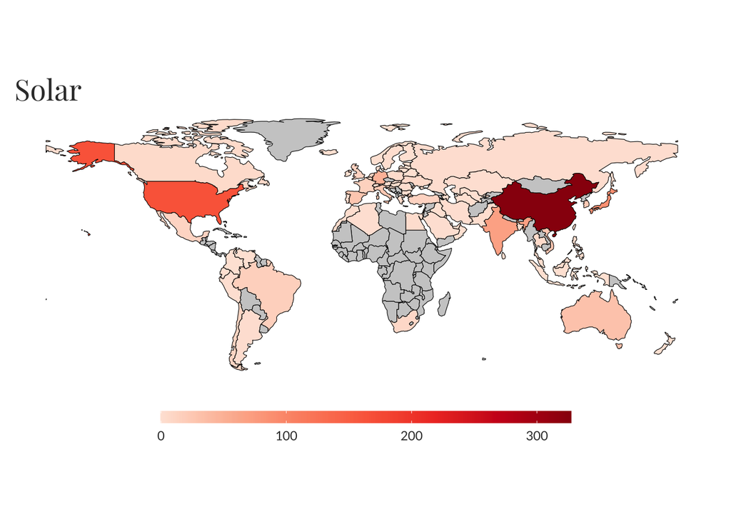

```r
owid_map(energia_solar)
```

**c.** gráfico de linha para a série de geração de energia solar para o Brasil, Alemanha, Estados Unidos e China:

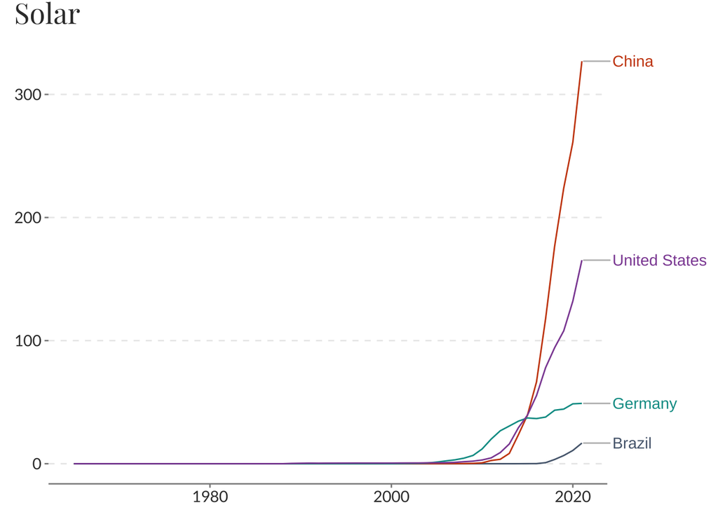

```r
owid_plot(energia_solar, summarise = FALSE, filter = c("Brazil", "Germany",
                                                       "United States", "China"))
```